# Data Analysis

#### **Description of the Problem**

We were given 30 State of the Nation (SONA) speeches from 1994 to 2018 to analyse. The specific objectives are to: 1. Infer sentiment and changes in sentiment over time  
2. Describe the topics that emerge  
3. Predict the President from a given sentence of text  
4. Evaluate out of sample performance of the predictions

#### **Approach**

We collaborated using the following GitHub location: **https://github.com/samperumal/dsi-assign2**.

We initially split the work as follows and each of us created a folder with our names to push our work to for others to view:  
- Neural Net - Sam and Merve - Bag of Words - Merve - Topic Modelling - Vanessa - Sentiment Analysis - Audrey

We presented our work to each other and made suggestions for improvement. Before diving into any prediction, we felt it is important to do an Exploratory Data Analysis (EDA) to get a sense of the high level overview of the dataset. This was done by Audrey.

The initial results from the Neural Net gave a 65% accuracy on the validation set and we wanted to feed the results of the Topic Modelling and Sentiment Analysis into the Neural Net to see if it would improve results so we needed to understand from each other what the output of these 2 methods was and the input required by the neural net to get the data into a useable format which took some discussion and a few iterations.

#### Data Preparation

Initially we each performed our own import of the data, splitting out the year and president and tokenisation but we realised there was duplication of effort here and different naming conventions which made it difficult to collaborate and use each other’s output. In addition, Sam noticed that some of the data was not being read in because of special characters and sentences were not being tokenised correctly for various reasons so he became responsible for performing the data clean up (preprocessing) and outputting a .RData file that we could all then use to rerun our work.

The data as provided consisted of 30 text files, with filenames encoding the president’s name, the year of the speech, and whether it was pre/post an election (which is absent in non-election years). In working through the files, we discovered that two files were identical which was corrected in the data source with replacement. Additionally, in reading the files, we also identified 3 files that had one or more bytes which caused issues with the standard R file IO routines. Specifically 1 file had a leading Byte-Order-Mark (BOM) which is unique to windows operating system files, and 2 other files had invalid unicode characters, which suggests a text-to-speech processing application was used and experienced either transmissionor storage errors. In all the cases the offending characters were simply removed from the input files.

Having fixed basic read issues, we then examined the content of each file and the simplistic tokenisation achieved by applying *unnest_tokens* to the raw lines read in from the files. Several issues were uncovered, and in each case a **regular expression** was created to correct the issue in the raw read lines:

- There are multiple characters which are not handled correctly by the default parser, particularly where unicode characters are substituted for standard ASCII characters or are erroneously inserted as part of the text capture. This range of characters were simply removed from the text: **"“”%’‘–+¬>-**.
- Forward-slashes were converted to a space, to handle both options (hot/cold) and numeric ranges (1998/99).
- Bullet-pointed lists are interpreted as a single, exceptionally long sentence by default. We chose to split this up into a lead-in sentence terminated by a colon, and a list of sentences starting after the bullet point character (*).
- Numbers (both with and without thousand separator characters) and currency values with leading currency symbols (R/$) were removed.
- Specific punctuation (ellipsis, colon, semi-colon) was considered equivalent to a sentence separator and converted to a full stop: **:;…¦…**.
- Full stops separated by only whitespace were considered redundany and collapsed to a single whitespace character.
- All contiguous whitespace was collapsed to a single whitespace character.
- The *unnest_tokens* function relies on each new sentence starting with a capital letter. After the above fixes, it was was therefore necessary to capitalise every character after full stop, to ensure it is recognised as the start of a new sentence.

Having fixed the text to allow correct sentence tokenisation, and applied the *unnest_tokens* function, we then determined a unique ID for each sentence by applying a hash digest function to the sentence text. This unique ID allowed everyone to work on the same data with confidence, and also enabled us to detect 72 sentences that appeared identically in at least 2 speeches. As these duplicates would potentially bias the analysis and training, all instances of duplicates were removed from the dataset.

One final note is that each speech starts with a very similar boiler plate referencing various attendees to the SONA in a single, run-on sentence. We believe this header does not add significantly to the content of the speech, and so we excluded all instances across all speeches.

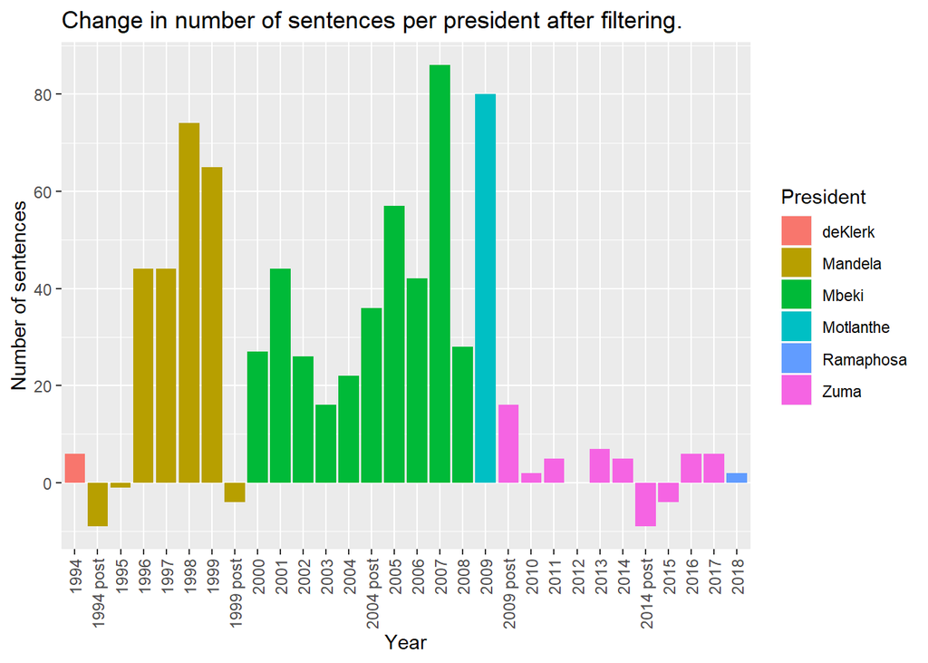

Change in number of sentences per president before and after filtering.

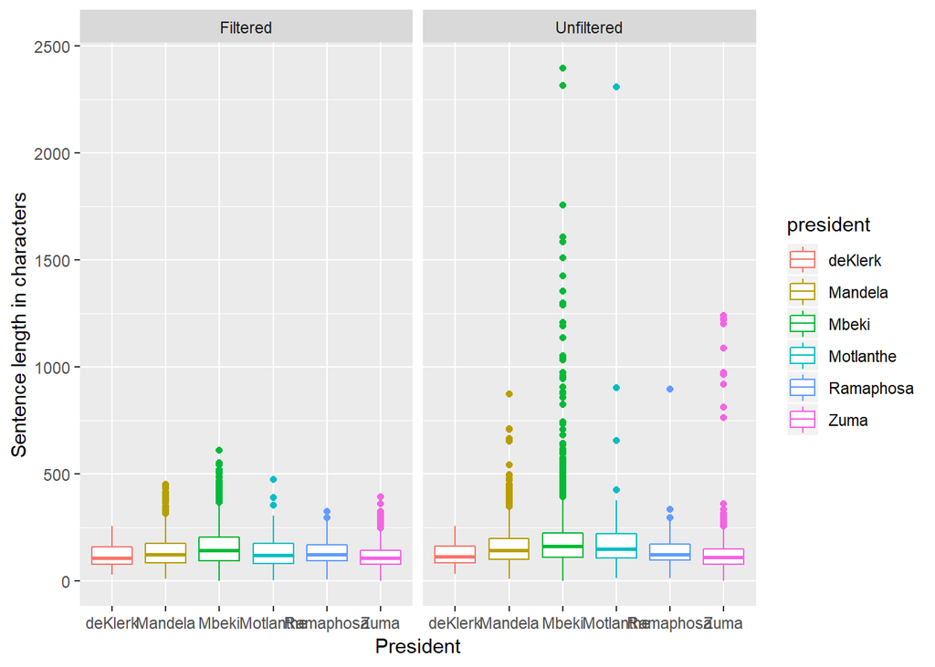

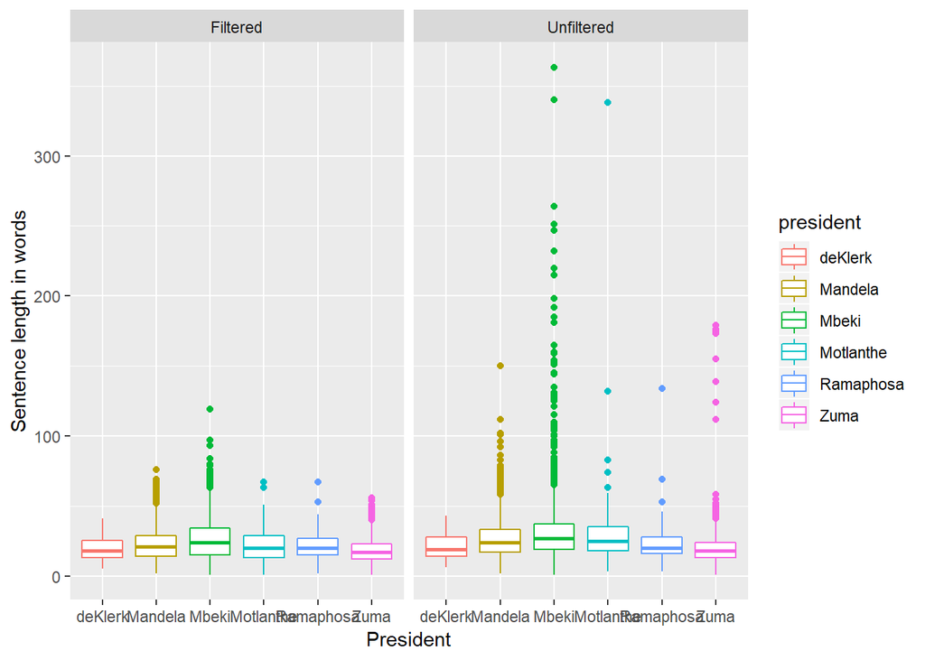

Overall there is a much tighter grouping of sentences, with less variation and more conistent lengths, which is useful for techniques which depend on equal length inputs. The final histogram below shows the histogram of number of sentences per year/president after filtering, which still bears the same basic shape as before filtering, but with a better profile.

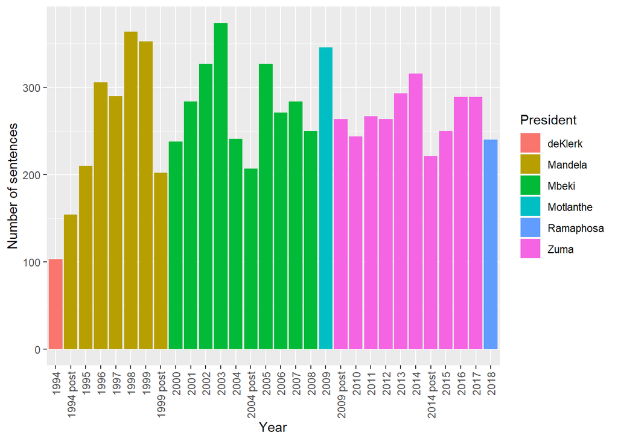

#### Data Split and Sampling

For all group work, we separated our full dataset into a random sampling of 80% training and 20% validation data, which was saved into a common .RData file. This ensured that there would be consistency across the data we were working on so that we could use each others work and compare results more easily.

The graphs above make it clear that our data is also very unbalanced. In an attempt to correct for this, we applied supersampling with replacement to the training dataset to ensure an equal number of sentences per president. Training was attempted using both balanced and unbalanced training data, but it did not appear to make much difference. Balancing was conducted on the training dataset only to ensure there are no duplicates in the validation set that might skew validation error.

#### **Overview of the dataset**

Each president has made a certain number of SONA speeches, depending on their term in office and whether there was 1 speech that year or 2 in the year of an election (pre and post election). Since the data is dependent on their term in the office it is unbalanced. Sentence counts per president after cleaning the data is :

```
## [1] "President sentence counts:"
```

```
##
##   deKlerk   Mandela     Mbeki Motlanthe Ramaphosa      Zuma
##       103      1879      2803       346       240      2697
```

```
## [1] "Baseline_accuracies"
```

```
##
##   deKlerk   Mandela     Mbeki Motlanthe Ramaphosa      Zuma
##  1.276648 23.289539 34.742191  4.288547  2.974715 33.428359
```

Let’s understand the number of words used by each President and how this varies across each SONA speech.

#### **Average number of words used per President**

We need to create a metric called “avg_words” which is simply the total number of words across all SONA speeches made by a particular president, divided by the total number of SONA speeches that president made.

Average number of words used per President

[output not shown]

## **Insights:**

On average, Mbeki used the most words in his SONA speeches, followed by Motlanthe and de Klerk used the least. Mandela and Zuma are ranked in the middle of their peers. The current president (Ramaphosa) used fewer words than all of his post 1994 peers.

#### **Number of words used per SONA**

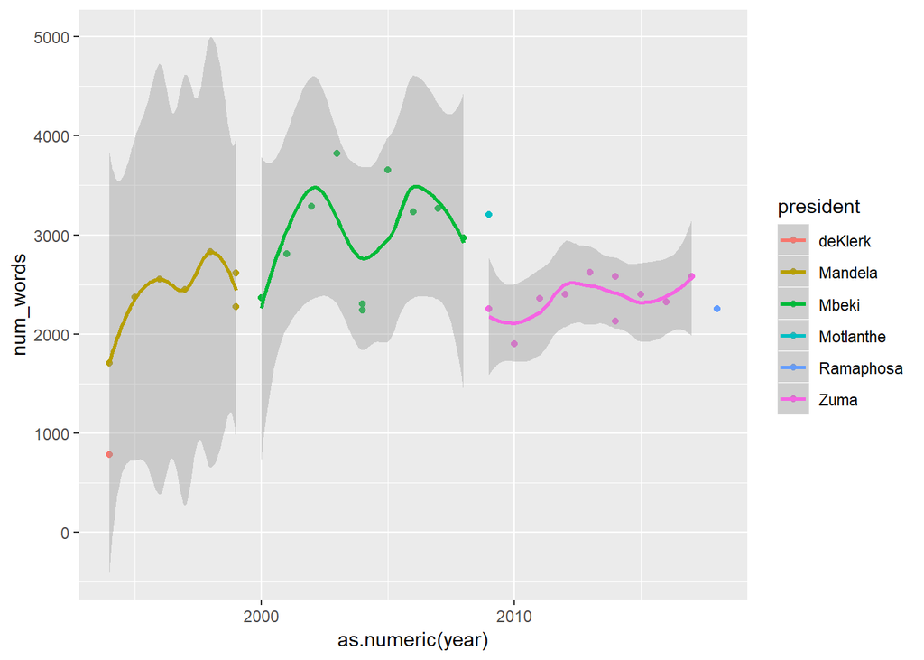

## **Insights:**

Of the 3 presidents that have made more than 1 SONA speech, Mbeki used more words on average than both Mandela and Zuma and the variance in the number of words used per SONA speech is also higher for Mbeki. In 2004, which was an election year, the average number of words Mbeki used was lower in both his pre- and post-election speeches. Towards the end of his term, his average number of words also dropped off. The data suggests that perhaps Mbeki’s average number of words is correlated with his confidence in being re-elected President.

## **Insights:**

#### **Lexical Diversity per President**

Lexical diversity refers to the number of unique words used in each SONA.

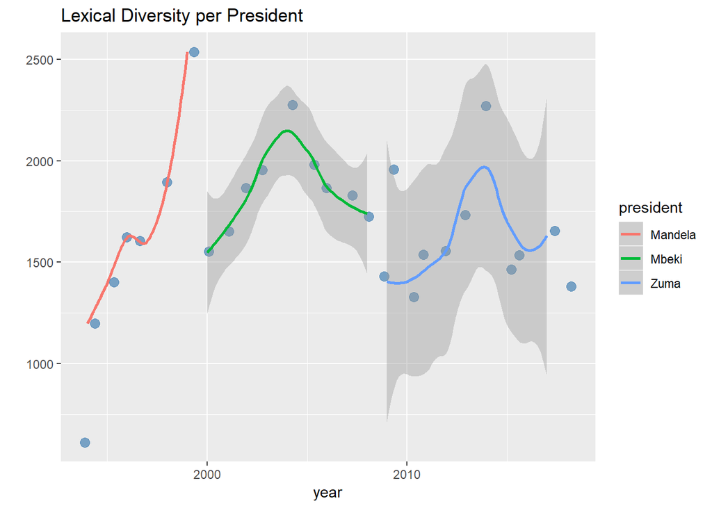

## **Insights:**

It’s interesting that whilst the trend in the number of unique words used was most often upwards with Mandela, Mbeki and Zuma both show a mostly upward trend in the lead up to the election year, followed by a mostly downward trend after nearing the 2500 unique words mark in their post election speech.

If we exclude the post election speeches, the number of unique words used by Mbeki during his term from 2000 to 2008 averages just under 2000 whereas the number of unique words used by Zuma during his term from 2009 to 2017 averages just over 1500.

#### **Lexical Density per President**

Lexical density refers to the number of unique words used in each SONA divided by the total number of words and a high value is an indicator of word repitition.

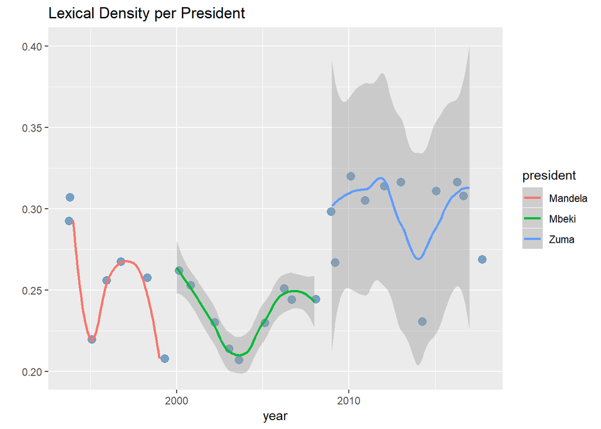

## **Insights:**

De Klerk repeated over 30% of his words in his 1994 pre election SONA speech. On average, Mandela repeated about 25% of words in each of his SONA speeches and this reduced to about 20% in the post election speech of 1999. Mbeki’s repitition rate was about 23% and this reduced to 20% in the post election speech of 2004. Zuma’s repitition rate is over 30% with the exception of his post election speech of 2014 at about 23%.

# **Results**

#### **Sentiment Analysis**

##### **Analysis of Sentiment using Single Words**

##### **Sentiment Analysis using “bing” lexicon**

The “bing” lexicon encodes words as either “positive” or “negative”. However, not all words used in the SONA speeches are in the lexicon so we need to adjust for this.

##### **Sentiment per President**

Let’s understand how many “positive” and “negative” words are used by each president across all their SONA speeches and create a metric called “sentiment” which is simply the total number of positive words minus the total number of negative words. We then adjust for the total number of words used from the lexicon in the “sentiment_score” metric.

Sentiment Score per President

| president | negative | positive | sentiment | sentiment_score |
| --- | --- | --- | --- | --- |
| Zuma | 788 | 1466 | 678 | 30.08 |
| Ramaphosa | 102 | 181 | 79 | 27.92 |
| Mbeki | 1314 | 2287 | 973 | 27.02 |
| Motlanthe | 180 | 263 | 83 | 18.74 |
| Mandela | 1036 | 1434 | 398 | 16.11 |
| deKlerk | 64 | 58 | -6 | -4.92 |

**Insights:**

Of the 3 presidents that have made more than 1 SONA speech, Zuma has the highest sentiment score, followed by Mbeki and then Mandela. Zuma’s sentiment score is nearly double Mandela’s. It’s interesting that the current President, Ramaphosa, has the second highest sentiment score, not far behind Zuma and only slightly ahead of Mbeki.

##### **What are the 10 positive words most frequently used by each president?**

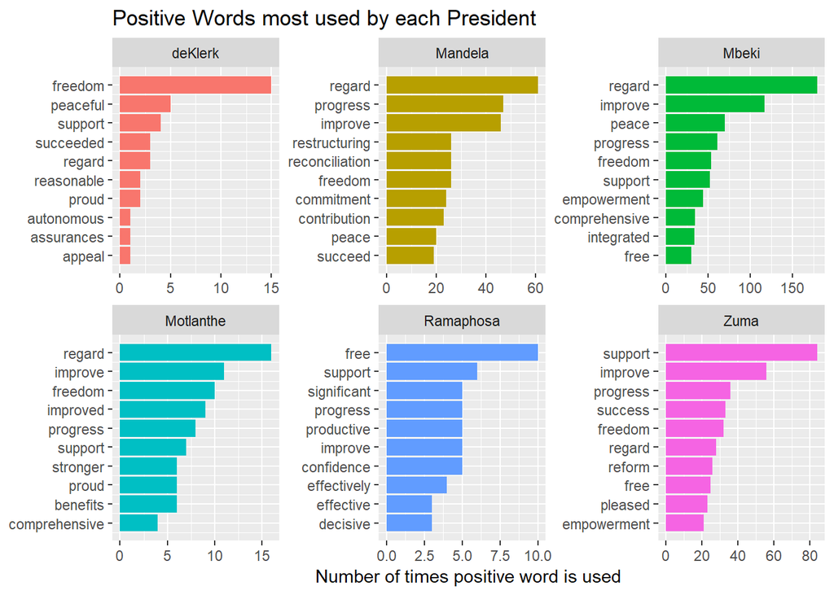

## **Insights:**

##### **Which of the positive words most frequently used are common across presidents?**

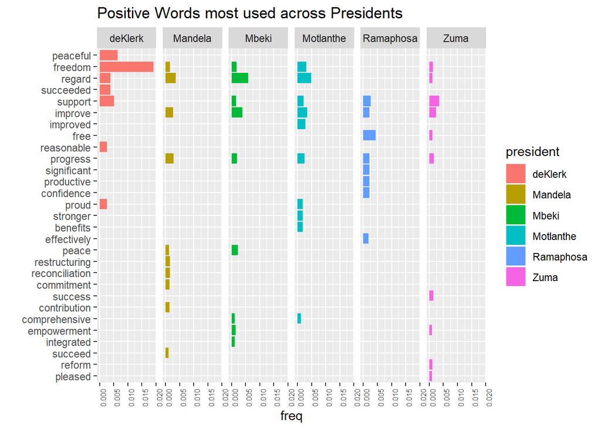

## **Insights:**

##### **What are the 10 negative words most used by each president?**

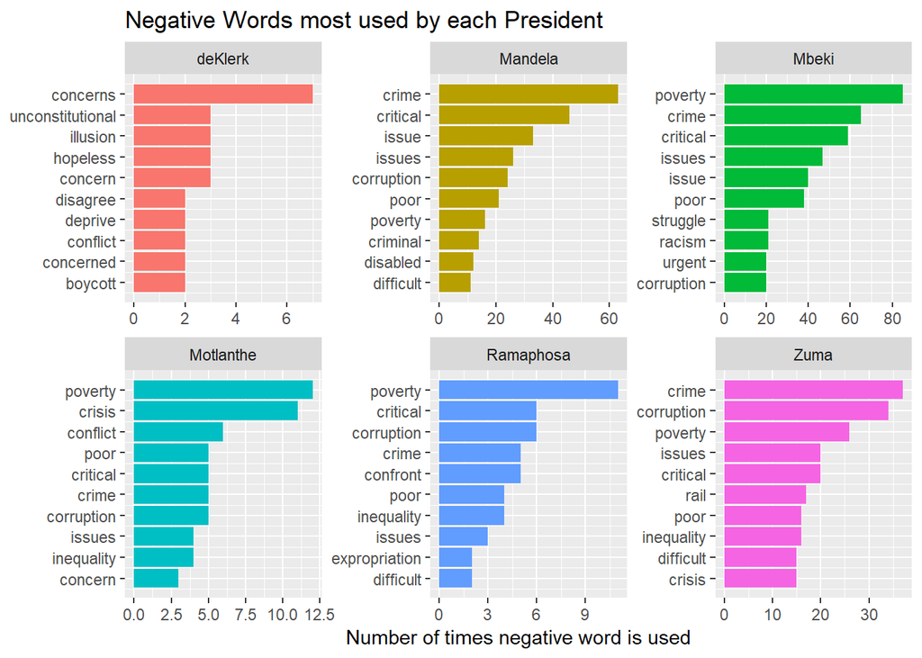

## **Insights:**

Common negative words pre 1994 include: “concerns”/“concern”/“concerned”, “unconstitutional”, “illusion”, “hopeless”, “disagree”, “deprive”, “conflict”, and “boycott”.

Common negative words post 1994 include: “corruption”, “crime”/“criminal”, “poverty”/“poor”, “inequality”, “issue”/“issues” and “crisis”.

##### **How many of the negative words most used were used by each president?**

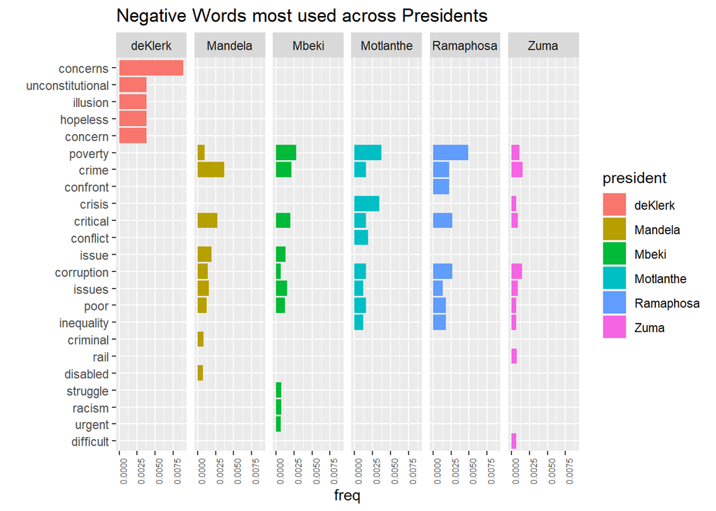

## **Insights:**

The interpretation is much the same as before. Note the clear separation between the top 10 negative words used pre and post 1994 elections, indicative of the pre and post apartheid regimes.

##### **What proportion of words used are positive vs negative?**

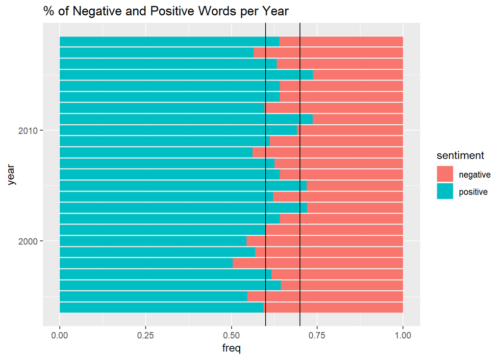

## **Insights:**

The 2 vertical black lines are drawn at 60% amd 70% positivity rates. In the majority of years, SONA speeches fall within this range of positivity however a there are a few more negative speeches in earlier years and a few more positive speeches in later years.

##### **Change in Sentiment over time**

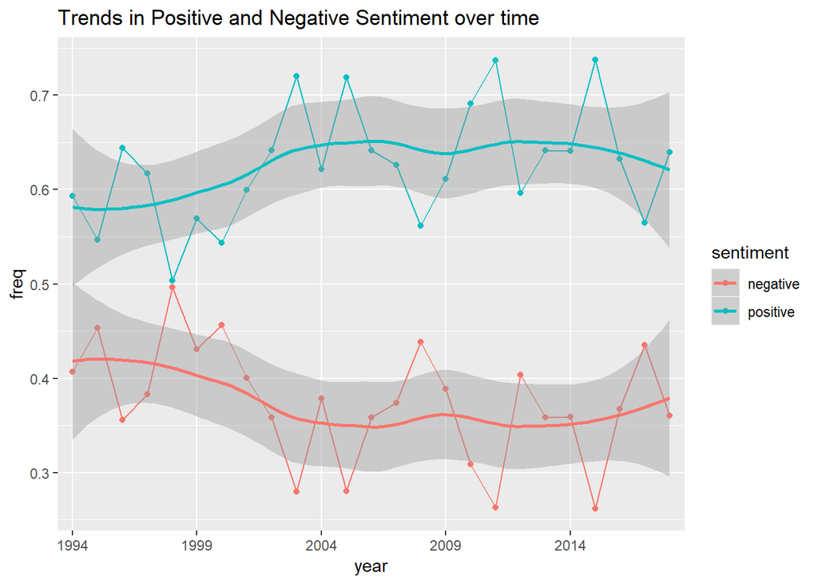

## **Insights:**

The trend appears to be more positive and less negative over time but how can we be sure?

We will test whether negative sentiment is increasing or decreasing, then we will test whether positive sentment is increasing or decreasing . We will use a Binomial model because the frequencies are between 0 and 1. Finally, we will test whether average sentiment is increasing or decreasing using a linear model.

##### **Is negative sentiment increasing over time?**

```
##
## Call:
## glm(formula = freq ~ as.numeric(year), family = "binomial", data = subset(sentiments_relative,
##     sentiment == "negative"))
##
## Deviance Residuals:
##      Min        1Q    Median        3Q       Max
## -0.21779  -0.05759   0.01224   0.07113   0.19692
##
## Coefficients:
##                   Estimate Std. Error z value Pr(>|z|)
## (Intercept)       25.88105  115.18655   0.225    0.822
## as.numeric(year)  -0.01316    0.05743  -0.229    0.819
##
## (Dispersion parameter for binomial family taken to be 1)
##
##     Null deviance: 0.39087  on 24  degrees of freedom
## Residual deviance: 0.33826  on 23  degrees of freedom
## AIC: 27.484
##
## Number of Fisher Scoring iterations: 3
```

## **Insights:**

The slope is negative but the beta of the year variable is not significant so we cannot conclude that negative sentiment is decreasing over time.

##### **Is postive sentiment increasing over time?**

```
##
## Call:
## glm(formula = freq ~ as.numeric(year), family = "binomial", data = subset(sentiments_relative,
##     sentiment == "positive"))
##
## Deviance Residuals:
##      Min        1Q    Median        3Q       Max
## -0.19692  -0.07113  -0.01224   0.05759   0.21779
##
## Coefficients:
##                   Estimate Std. Error z value Pr(>|z|)
## (Intercept)      -25.88105  115.18655  -0.225    0.822
## as.numeric(year)   0.01316    0.05743   0.229    0.819
##
## (Dispersion parameter for binomial family taken to be 1)
##
##     Null deviance: 0.39087  on 24  degrees of freedom
## Residual deviance: 0.33826  on 23  degrees of freedom
## AIC: 27.484
##
## Number of Fisher Scoring iterations: 3
```

## **Insights:**

The slope is positive but the beta of the year variable is not significant so we cannot conclude that positive sentiment is increasing over time.

##### **Is average sentiment increasing over time?**

```
##
## Call:
## glm(formula = avg_sentiment ~ as.numeric(year), family = "gaussian",
##     data = sentiments_per_year)
##
## Deviance Residuals:
##     Min       1Q   Median       3Q      Max
## -21.252   -7.877   -1.282    8.584   21.444
##
## Coefficients:
##                    Estimate Std. Error t value Pr(>|t|)
## (Intercept)      -1369.9476   652.4104  -2.100   0.0460 *
## as.numeric(year)     0.6952     0.3253   2.137   0.0425 *
## ---
## Signif. codes:  0 '***' 0.001 '**' 0.01 '*' 0.05 '.' 0.1 ' ' 1
##
## (Dispersion parameter for gaussian family taken to be 153.4216)
##
##     Null deviance: 4536.4  on 26  degrees of freedom
## Residual deviance: 3835.5  on 25  degrees of freedom
## AIC: 216.44
##
## Number of Fisher Scoring iterations: 2
```

## **Insights:**

But we need to be cautious with this interpretation because what could actually be going on here is that the “bing”" lexicon has more than double the number of negative words than positive words so this could be influencing the results and SONA speeches may in fact be more positive than they appear to be.

```
##
## negative positive
##     4782     2006
```

##### **Distribution of “bing” Sentiment per President**

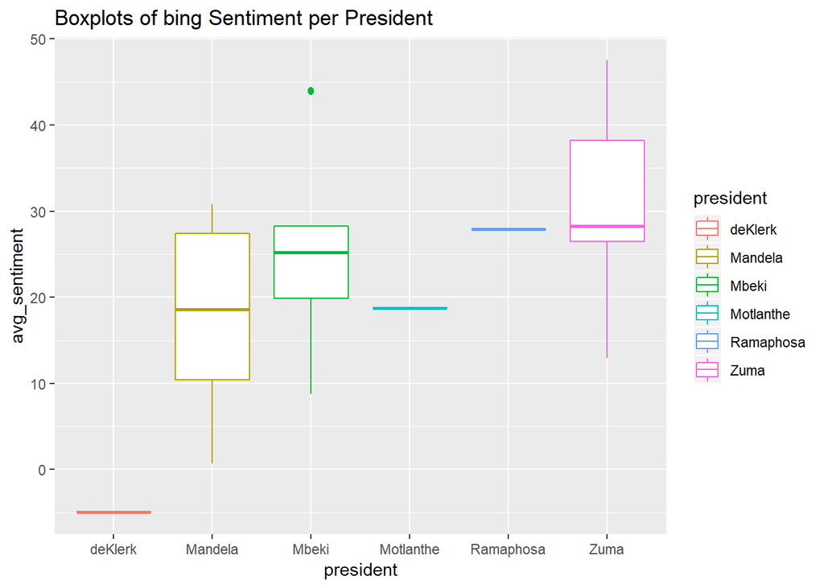

## **Insights:**

Apart from the last 2 presidents, Ramaphosa and Zuma, the presidents are in time order. We can see that other than Motlanthe, the trend is an increasing average sentiment over time but at a decreasing rate. The interquartile range of Mbeki is smaller than Zuma’s which is smaller than Mandela’s.

##### **Change in “bing” Sentiment over time**

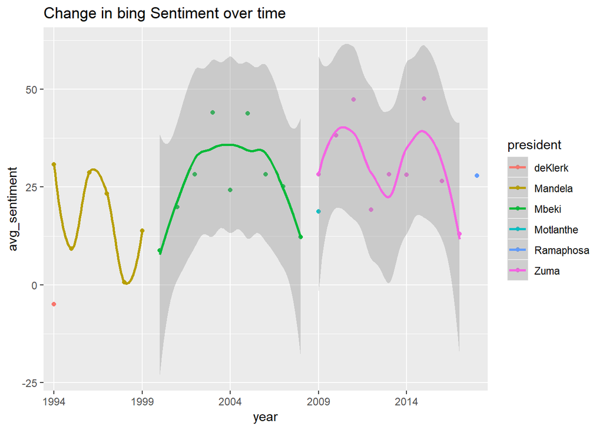

## **Insights:**

Average sentiment is the proportion of positive words out of all the words in the “bing” lexicon. Mandela shows a very erratic average sentiment, ranging from 0 to over 25. Mbeki and Zuma’s average sentiment mostly ranges between 25 and 50, with the exception of a few such as 2000, 2008, 2012, 2017.

##### **Sentiment Analysis using “afinn” lexicon (scale from -5 negative to +5 positive)**

afinn Sentiment

| score | n | weighted_score |
| --- | --- | --- |
| -5 | 2 | -10 |
| -4 | 27 | -108 |
| -3 | 689 | -2067 |
| -2 | 1059 | -2118 |
| -1 | 867 | -867 |
| 1 | 2422 | 2422 |
| 2 | 3525 | 7050 |
| 3 | 379 | 1137 |
| 4 | 42 | 168 |
| 5 | 32 | 160 |

## **Insights:**

The most number of words are scored positive 2, followed by positive 1. This becomes even more pronounced when scores are multiplied by counts to get weighted scores.

Let’s check the distribution of all “afinn” words:

```
##
##  -5  -4  -3  -2  -1   0   1   2   3   4   5
##  16  43 264 965 309   1 208 448 172  45   5
```

Words with a score of -2 dominate the lexicon, followed by words with a score of 2. We found a relatively high number of words with a score of 2 in this analysis but it is unlikely to only be a result of its prevalence in the lexicon and we can conclude that it is probably an accurate assessment of the sentiment that prevails in the text.

##### **Distribution of “afinn” Sentiment per President**

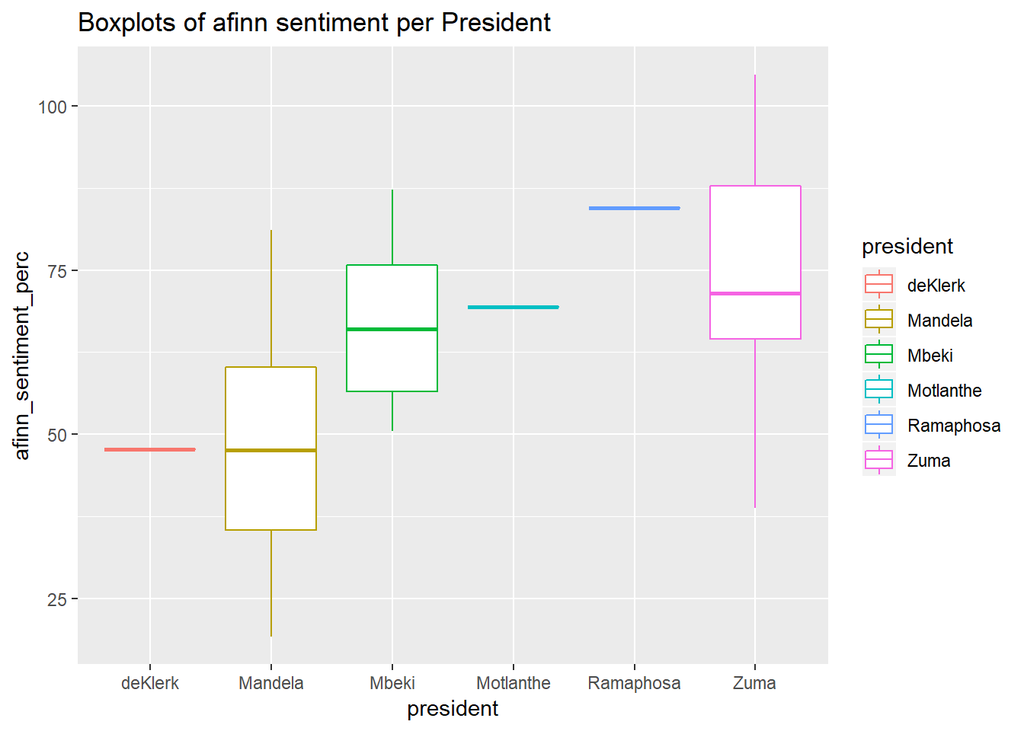

## **Insights:**

The interpretation is much the same as with the “bing” lexicon in that the trend is an increasing average sentiment over time however Zuma’s median sentiment is lower than the general trend.

##### **Change in “afinn” Sentiment over time**

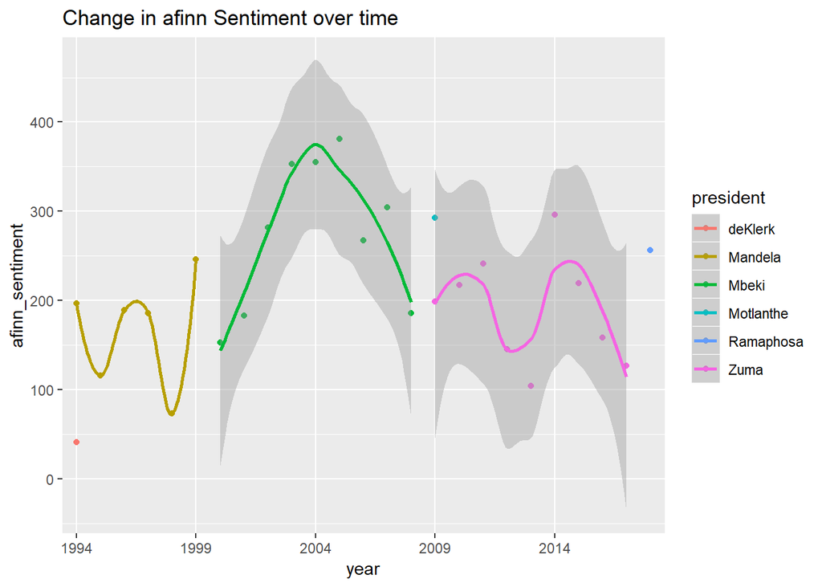

## **Insights:**

Mandela and Zuma show a wave-like pattern of sentiment. Mbeki shows an increasing and then decreasing pattern.

##### **Sentiment Analysis using “nrc” lexicon (infers emotion with certain words)**

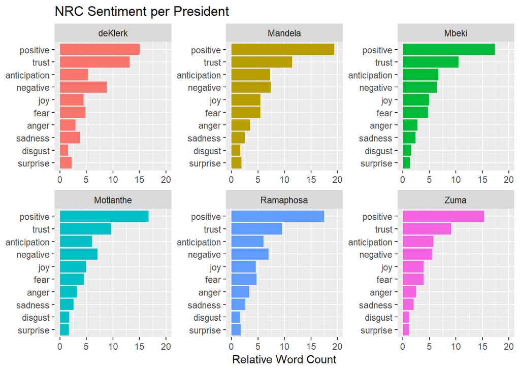

Let’s check the distribution of all “nrc” words:

```
##
##        anger anticipation      disgust         fear          joy
##         1247          839         1058         1476          689
##     negative     positive      sadness     surprise        trust
##         3324         2312         1191          534         1231
```

## **Insights:**

Words can be assigned more than 1 sentiment but we do not expect as many words to come up under “anticipation”, “joy” or “surprise” given the relatively lower counts in the lexicon. So “anticipation” has a surprisingly high relative count across all presidents.

##### **Sentiment Analysis using “nrc” lexicon**

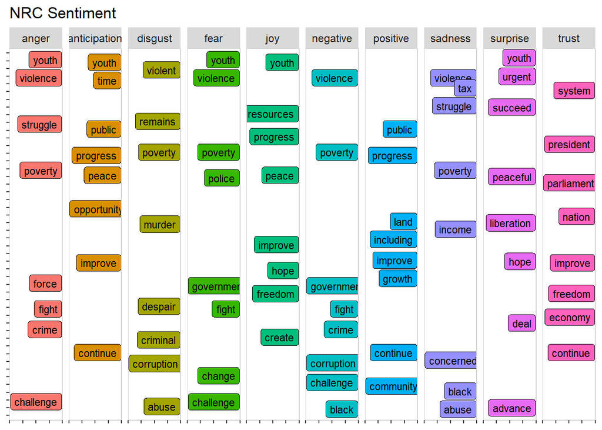

## **Insights:**

The negative most used words which are also associated with the “anger”, “disgust”, fear" and “sadness” emotions are: “violence”, “struggle” and “poverty”.

The positive most used words which are also associated with the “anticipation”, “joy” and surprise" emotions are: “youth”, “public” and “progress”.

The most usedwords that evoke the “trust” emotion are: “system”, “president”, “parliament” and “nation”.

## **Neural Nets**

### **Neural Net with Bag of Words Data**

The count of each word that have been used in each sentence is what we are going to be feeding in. We need to unnest the sentence data, count each word in each sentence and spread the sentence word counts so that we have sentence id’s in each row and we have each word as column id’s. This is the simplest neural net model that we can try, so that was our first model.

This model has L2 regularization to avoid overfitting but even so it didn’t help very much. The accuracy is 0.55886. The optimizer_rmsprop has learning rate 0.003. This was choosen after trying lr=c(0.001, 0.002, 0.003) To make readability easier the model with best learning rate is used.

Kappa value tells you how much better your classifier is performing over the performance of a classifier that simply guesses at random according to the frequency of each class.

### **Neural Net with tf-idf Data**

TFIDF is a statisic that shows how important a word is to it’s corpus. So if we are feeding NN with TFIDF we are logically expecting the results to be slightly better than the word-cout NN model.

The accuracy is 0.6158 and the model starts overfitting after fourth epoch. So this is slightly better than the bag of words word-count model as we expected.

### **Neural Net with Sentiment Analysis Data**

Sentiment analysis also reaches it’s smallest validation loss value on the fifth iteration. But the train accuracy and test accuracy is changing very slightly at each iteration. This model does not seem to be doing well on eighter the training set or the test set. The test accuracy is 0.4361834 and the training accuracy is 0.4353395. If we look at the NRC sentiment lexicon it is visible that all presidents share same sentiment distribution pattern, so this is why it is not overfitting. Because our set aside test set is actually no different than the training set.

### **Neural Nets with Topic Modelling Data (Gamma Values)**

Topic modelling only predicted for president 1(Mbeki) and president 2(Zuma).

The train and the test set are not very distinct from each other just like sentiment analysis. If we look at the mixture of the topics by each president in topic modelling chunk we can see that all the topics for each president are kind of uniformed and hard to seperate each president’s topic from one another.

### **CNN with Transfer Learning (Pre-trained Embeddings)**

We will be using GloVe embeddings. GloVe stands for “Global Vectors for Word Representation” and is an unsupervised learning algorithm for obtaining vector representations for words as it is stated in their website. Training is performed on aggregated global word-word co-occurrence statistics from a corpus, and the resulting representations showcase interesting linear substructures of the word vector space. [Reference:Jeffrey Pennington, Richard Socher, and Christopher D. Manning. 2014. GloVe: Global Vectors for Word Representation:https://nlp.stanford.edu/pubs/glove.pdf ] Specifically, we will use the 100-dimensional GloVe embeddings of 400k words computed on a 2014 dump of English Wikipedia.

This note is taken from the reference given above and as they state the accuracy they achieved on python is twice as good.

“IMPORTANT NOTE:This example does yet work correctly. The code executes fine and appears to mimic the Python code upon which it is based however it achieves only half the training accuracy that the Python code does so there is clearly a subtle difference. We need to investigate this further before formally adding to the list of examples”

[reference for implementation on Python: https://blog.keras.io/using-pre-trained-word-embeddings-in-a-keras-model.html] [reference for implementation on R: https://keras.rstudio.com/articles/examples/pretrained_word_embeddings.html] [reference for implementation on R: https://github.com/rstudio/keras/blob/master/vignettes/examples/pretrained_word_embeddings.R]

Also for the pre-trained embeddings to work well it needs to be trained with similar type of data that you are trying to classify, and the fact that the GloVe embeddings are trained on Wikipedia data one can expect that it would not neccesarily help predict the presidents better for our sentences.

Majority of the sentences of Mbeki is predicted as Mandela(379/569). Majority of the sentences of Zuma is predicted as Mandela (244/534) and the secon majority is predicted as himself (195/534). Majority of the sentences of Mandela is predicted as Mandela(263/381). Majority of the sentences of Mothlane(38/66) is predicted as Mandela. Majority of sentences of Ramaphosa is predicted as Mandela(19/47) or Zuma(15/47). Mojority of the sentences of deKlerk is predicted as Mandela(14/17).

## **References**

https://www.kaggle.com/rtatman/tutorial-sentiment-analysis-in-r

https://www.datacamp.com/community/tutorials/sentiment-analysis-R

https://nlp.stanford.edu/pubs/glove.pdf

https://blog.keras.io/using-pre-trained-word-embeddings-in-a-keras-model.html

https://keras.rstudio.com/articles/examples/pretrained_word_embeddings.html

https://github.com/rstudio/keras/blob/master/vignettes/examples/pretrained_word_embeddings.R

Landis, J.R.; Koch, G.G. (1977). “The measurement of observer agreement for categorical data”. Biometrics 33 (1): 159-174